# Practical Machine Learning Course Project

Rodrigo Araujo

August 3, 2016

## Overview

The goal of this project is to predict the quality in which some exercises were preformed. The data for this project come from http://groupware.les.inf.puc-rio.br/har, and contain information from accelerometers on the belt, forearm, arm, and dumbell of 6 participants. They were asked to perform the exercises in 5 different ways, which are described below:

- (Class A) exactly according to the specification
- (Class B) throwing the elbows to the front
- (Class C) lifting the dumbbell only halfway
- (Class D) lowering the dumbbell only halfway
- (Class E) throwing the hips to the front

We want to predict the classes (A, B, C, D, or E) of **20** different test cases.

## Data loading

First, we download and load the data that is available at

training data: https://d396qusza40orc.cloudfront.net/predmachlearn/pml-training.csv

test data: https://d396qusza40orc.cloudfront.net/predmachlearn/pml-testing.csv

```r
if(!dir.exists("data")){
  dir.create("data")
}

url_train_file <- "https://d396qusza40orc.cloudfront.net/predmachlearn/pml-training.csv"
url_test_file <- "https://d396qusza40orc.cloudfront.net/predmachlearn/pml-testing.csv"

download.file(url_train_file, destfile = "./data/pml-training.csv", method = "curl")
download.file(url_test_file, destfile = "./data/pml-testing.csv", method = "curl")

dateDownloaded <- date()

training_data <- read.csv("./data/pml-training.csv", header = TRUE, na.strings = c("", "NA", "#DIV/0!"))
testing_data <- read.csv("./data/pml-testing.csv", header = TRUE, na.strings = c("", "NA", "#DIV/0!"))
```

## Data Cleaning

Before any further analysys, it is important to make the data tidy by gettinng ride of the covariates (features) that are missing a lot of data and changing data types that might have been imported erroniously, for example the columns `cvtd_timestamp`, wich has a date type was imported as a Factor, besides that, `kurtosis_yaw_belt` and `skewness_yaw_belt`, which are supposed to be numeric columns were imported as logical. Although these columns were wrongly imported and they are supposed to be fixed, in this specific case they can actually be removed all together since they have a lot of NA’s. These variables only has actual values when `new_window == 'yes'`, which make then very sparse. Therefore all the `kurtosis_`, `skewness_`, `max_`, `min_`, `amplitude_`, `var_total_accel_`, `avg_`, and `stddev_` where eliminated from the original data frame by using the `cleanData` function described below.

```r
str(training_data, list.len = 17)
```

```
## 'data.frame':    19622 obs. of  160 variables:
##  $ X                       : int  1 2 3 4 5 6 7 8 9 10 ...
##  $ user_name               : Factor w/ 6 levels "adelmo","carlitos",..: 2 2 2 2 2 2 2 2 2 2 ...
##  $ raw_timestamp_part_1    : int  1323084231 1323084231 1323084231 1323084232 1323084232 1323084232 1323084232 1323084232 1323084232 1323084232 ...
##  $ raw_timestamp_part_2    : int  788290 808298 820366 120339 196328 304277 368296 440390 484323 484434 ...
##  $ cvtd_timestamp          : Factor w/ 20 levels "02/12/2011 13:32",..: 9 9 9 9 9 9 9 9 9 9 ...
##  $ new_window              : Factor w/ 2 levels "no","yes": 1 1 1 1 1 1 1 1 1 1 ...
##  $ num_window              : int  11 11 11 12 12 12 12 12 12 12 ...
##  $ roll_belt               : num  1.41 1.41 1.42 1.48 1.48 1.45 1.42 1.42 1.43 1.45 ...
##  $ pitch_belt              : num  8.07 8.07 8.07 8.05 8.07 8.06 8.09 8.13 8.16 8.17 ...
##  $ yaw_belt                : num  -94.4 -94.4 -94.4 -94.4 -94.4 -94.4 -94.4 -94.4 -94.4 -94.4 ...
##  $ total_accel_belt        : int  3 3 3 3 3 3 3 3 3 3 ...
##  $ kurtosis_roll_belt      : num  NA NA NA NA NA NA NA NA NA NA ...
##  $ kurtosis_picth_belt     : num  NA NA NA NA NA NA NA NA NA NA ...
##  $ kurtosis_yaw_belt       : logi  NA NA NA NA NA NA ...
##  $ skewness_roll_belt      : num  NA NA NA NA NA NA NA NA NA NA ...
##  $ skewness_roll_belt.1    : num  NA NA NA NA NA NA NA NA NA NA ...
##  $ skewness_yaw_belt       : logi  NA NA NA NA NA NA ...
##   [list output truncated]
```

Besides, the listed features, some other features such as `X`, `raw_timestamp_part_1`, `raw_timestamp_part_2`, `cvtd_timestamp`, `new_window` do not contribute to the prediction and were also removed by the `cleanData` function.

```r
cleanData <- function(data){
  data <- subset(data, select=-c(X, raw_timestamp_part_1, raw_timestamp_part_2, cvtd_timestamp, new_window))
  data <- data[,colSums(is.na(data)) < 1] # Remove columns that mainly contain NA's
  return(data)
}

training_data <- cleanData(training_data)
testing_data <- cleanData(testing_data)
```

## Partition Data

Before exploring and training a model, it is necessary to partiotion the data into two subsets, one that will be used to train the model and a second portion that will be used to validate our trained mode, or get the out-of-sample error of the model. We propose a 70/30 partition, where 70% of the date is used for training and 30% of the date is used for testing.

```r
library(caret)
set.seed(123)
inTrain <- createDataPartition(y = training_data$classe, p = 0.70, list = FALSE)

training <- training_data[inTrain,]
testing <- training_data[-inTrain,]
```

## Exploratory Analysis

If we analyse the densities of several features 3 by 3 (e.g. `magnet_dumbbell_x`, `magnet_dumbbell_y`, `magnet_dumbbell_z`) it is not obvious that a linear classifier can seperate the 5 classes correctly. See density plot below.

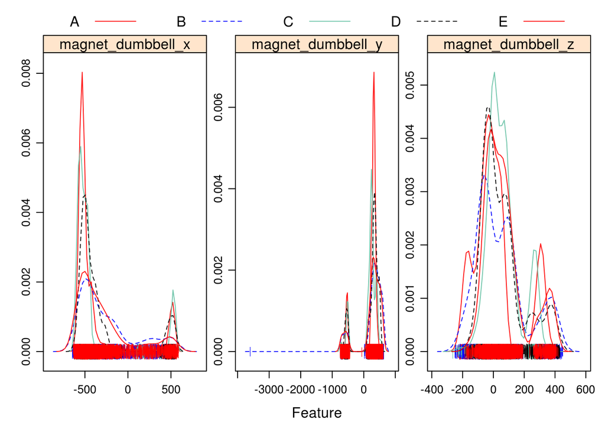

Therefore, a classifier that can perform better in nonlinear settings would be a better choice.

## Training Predictive Models

We started by training a classification tree because they are easy to interpret, has good performance in nonlinear settings, they use interactions between variables, and they don’t need a lot of data transformation. We used `rpart` method and a 10-fold crossvalidation with different complexity parameters to avoid overfiting.

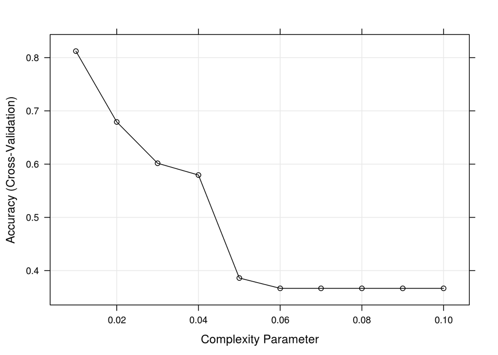

```r
grid <-  expand.grid(cp=c(1:10)*0.01)
fit_rpart_10k <- train(classe ~ ., data=training, method="rpart", tuneGrid=grid, trControl=trainControl(method="cv", number=10))
plot(fit_rpart_10k)
```

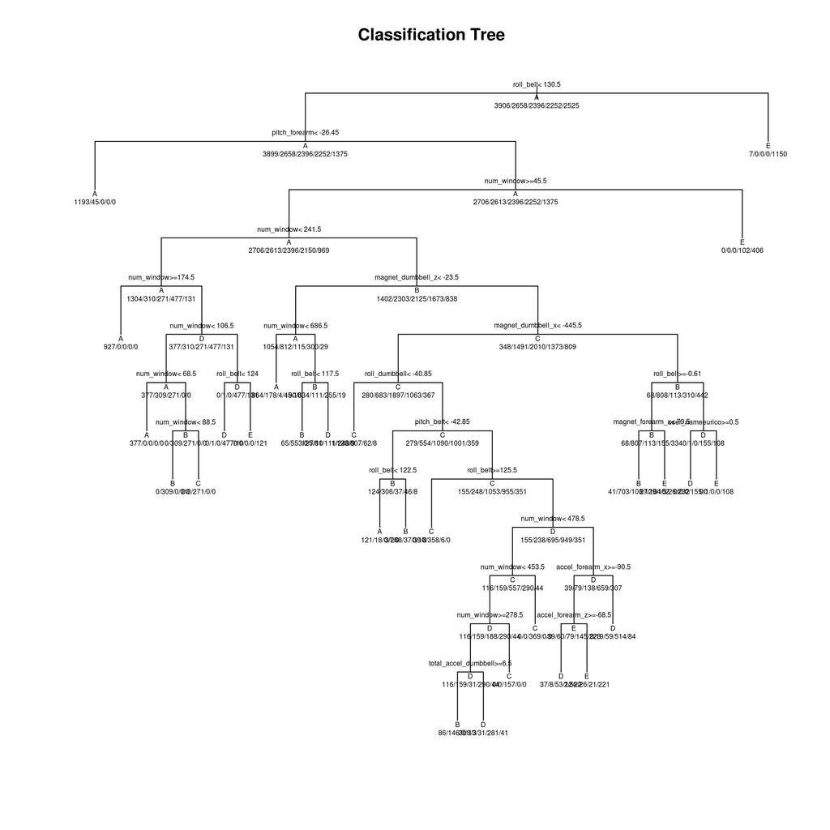

```r
plot(fit_rpart_10k$finalModel, uniform=TRUE,
      main="Classification Tree")
text(fit_rpart_10k$finalModel, use.n=TRUE, all=TRUE, cex=.5)
```

```r
# Predict in the test set (out-of-sample-error)
rpart10k_pred <- predict(fit_rpart_10k, newdata = testing)
confusionMatrix(rpart10k_pred, testing$classe)$table
```

```
##           Reference
## Prediction    A    B    C    D    E
##          A 1496  114    3   18    7
##          B   74  843   55   71   44
##          C    0   57  830   37    3
##          D   84   51  124  778   68
##          E   20   74   14   60  960
```

```r
confusionMatrix(rpart10k_pred, testing$classe)$overall["Accuracy"]
```

```
##  Accuracy
## 0.8338148
```

When runing the predictive model on the test set, we get an accuracy of 0.8338148, which is a good accuracy, but we want to see if we can get better results.

Next, we trained a random forest predictor, which is usually one of the two top performing algorithms in competitions.

```r
library(randomForest)
fit_rf <- randomForest(classe ~. , data=training, importance=T)

rf_pred <- predict(fit_rf, newdata = testing)
cm <- confusionMatrix(rf_pred, testing$classe)
confusionMatrix(rf_pred, testing$classe)
```

```
## Confusion Matrix and Statistics
##
##           Reference
## Prediction    A    B    C    D    E
##          A 1674    0    0    0    0
##          B    0 1139    7    0    0
##          C    0    0 1019    6    0
##          D    0    0    0  957    0
##          E    0    0    0    1 1082
##
## Overall Statistics
##
##                Accuracy : 0.9976
##                  95% CI : (0.996, 0.9987)
##     No Information Rate : 0.2845
##     P-Value [Acc > NIR] : < 2.2e-16
##
##                   Kappa : 0.997
##  Mcnemar's Test P-Value : NA
##
## Statistics by Class:
##
##                      Class: A Class: B Class: C Class: D Class: E
## Sensitivity            1.0000   1.0000   0.9932   0.9927   1.0000
## Specificity            1.0000   0.9985   0.9988   1.0000   0.9998
## Pos Pred Value         1.0000   0.9939   0.9941   1.0000   0.9991
## Neg Pred Value         1.0000   1.0000   0.9986   0.9986   1.0000
## Prevalence             0.2845   0.1935   0.1743   0.1638   0.1839
## Detection Rate         0.2845   0.1935   0.1732   0.1626   0.1839
## Detection Prevalence   0.2845   0.1947   0.1742   0.1626   0.1840
## Balanced Accuracy      1.0000   0.9993   0.9960   0.9964   0.9999
```

The results were much better compared to `rpart`, achieving 99.7621071% accuracy on the test set, although it was much slower, and we lost the nicer interpretability of the classification tree.

## Predicting New Data and Conclusion

Finally, we haven chosen the random forester model to predict the 20 new data, since this model achieved 99.7621071% accuracy. Here is the final prediction.

```
##  1  2  3  4  5  6  7  8  9 10 11 12 13 14 15 16 17 18 19 20
##  B  A  B  A  A  E  D  B  A  A  B  C  B  A  E  E  A  B  B  B
## Levels: A B C D E
```